# Exploring metabolism-growth relationships within and across individual fish.

E. Hoots and P. Biro

2025-10-31

# READ ME

This R code is used to take raw respirometry slopes measured on *Galaxias maculatus* at Deakin’s Marine Research Centre in Queenscliff, Victoria, Australia and calculate their standard, routine, and maximum metabolic rate. These metabolic measurements are made repeatedly on known individuals held under one of two temperature treatments (18°C or 23°C), and paired with repeated mass and length measurements over five month of data collection (May - September, 2023). After reading in all data, a multivariate mixed effects modeling approach is undertaken in order to assess covariance between growth and metabolism traits among- and within-individuals.

# CONTACT

Elizabeth C. Hoots

Email: beth.hoots@research.deakin.edu.au

GitHub: https://github.com/E-Hoots-Research

Web: https://elizabeth-hoots.owlstown.net/

# LOAD REQUIRED PACKAGES

```r
# installs and loads packages, need to install "pacman" first

pacman::p_load("brms",
               "broom",
               "broom.mixed",
               "car",
               "coda",
               "dplyr",
               "ggeffects",
               "ggiraphExtra",
               "ggplot2",
               "ggpubr",
               "hms",
               "lme4",
               "lmerTest",
               "lubridate",
               "nlme",
               "posterior",
               "readxl",
               "tidyverse"
)
```

## Working directories

```r
wd <- getwd() # getwd tells us what the current wd is, we are using this to drop it in a variable called wd

raw_data_wd <- paste0(wd, "./00_raw_data")  # creates a variable with the name of the wd where raw data are stored

    MRcalcs_wd <- paste0(raw_data_wd, "./MRcalcs")

    MR_slopes_wd <- paste0(raw_data_wd, "./MR_Slopes")

    MMR_wd <- paste0(raw_data_wd, "./MMR")

metadata_wd <- paste0(wd, "./01_metadata")  # creates a variable with the name of the wd where metadata are stored

figures_wd <- paste0(wd, "./03_figures")  # creates a variable with the name of the wd where figures are to be stored
```

# Read in data, calculate metabolic rates, merge into master data table

```r
#calcSMR function adapted from Chabot, 2016 (https://doi.org/10.1111/jfb.12845)
#note that we have not used the mlnd function as the mean of the lowest 10th percentile was better suited to our data

calcSMR <- function(Y) {
  u <- sort(Y)
  tenpc <- round(0.1 * length(u))
  SD10pc <- sd(u[1:tenpc])
  low10pc = mean(u[(which((u > (mean(u[1:tenpc])-SD10pc)))):(tenpc+which((u > (mean(u[1:tenpc])-SD10pc -u[1]))))])
  return(list(low10pc = low10pc))
}

# Define a function to extract date strings from file names
extract_date <- function(files) {
  gsub(".*?([0-9]{8}).*", "\\1", basename(files))
}

# Specify the directories where your files are located
csv_folder <- MR_slopes_wd
xlsx_folder <- MMR_wd

# Get the list of files in each folder
csv_files <- list.files(csv_folder, pattern = "_MR_slopes.csv", full.names = TRUE)
xlsx_files <- list.files(xlsx_folder, pattern = "_MMR.xlsx", full.names = TRUE)


# Extract date strings from file names
csv_dates <- extract_date(csv_files)
xlsx_dates <- extract_date(xlsx_files)


matching_files <- Map(function(date) {
  csv_file <- csv_files[grep(date, csv_dates)]
  xlsx_file <- xlsx_files[grep(date, xlsx_dates)]
  return(list(csv = csv_file, xlsx = xlsx_file))
}, unique(c(csv_dates, xlsx_dates)))


# Loop through matching files and perform your data processing
for (i in seq_along(matching_files)) {
  date <- unique(csv_dates)[i]
  current_files <- matching_files[[i]]  # Renamed 'files' to 'current_files'

  # Process CSV data
  tb_respirometry <- read_csv(current_files$csv) %>%
    rename(
      chamber_ch = Chamber.No,
      ID_fish    = Ind,
      mass       = Mass,
      length     = Length,
      volume_ch  = Ch.Volume,
      DOunit     = DO.unit,
      dateTime   = Date.Time,
      Temp_class = Temp.class,
      slope_wBR  = Slope.with.BR,
      BRSlope    = BR.Slope
    )  %>%
    mutate(
      dateTime       = as.POSIXct(ymd_hms(dateTime)),
      Time           = as_hms(ymd_hms(dateTime)),
      Date           = as.Date(dateTime, format = "%Y/%m/%d"),
    )


  tb_respirometry <- tb_respirometry %>%
    mutate(
      volume_net = volume_ch - mass,
      MR_wBR     = abs(slope_wBR)*(volume_net/1000)*60*60, #uncomment for mgO2/hr instead
      BR         = BRSlope*(volume_ch/1000)*60*60,
      MR         = MR_wBR + BR,
      BR_perc    = (BR/MR_wBR)*100
    )

  #Calculate RMR and variance in MR for each fish, create a new table for individual RMR calcs

  tb_rmr <- tb_respirometry %>%
    group_by(chamber_ch) %>%
    arrange(chamber_ch, dateTime) %>%
    slice(3:(n() - 1)) %>%
    ungroup()  %>%
    group_by(
      ID_fish, mass, length, volume_net, chamber_ch, Temp_class
    ) %>%
    arrange(ID_fish) %>%
    drop_na() %>%
    summarise(
      RMR        = mean(MR),
      RMR_var    = var(MR),
      RMR_perc   = (RMR_var/RMR)*100,
      time_start = dateTime %>% min(),
      time_end   = dateTime %>% max()
    )

  #Calculate SMR for each fish, create a new table for individual SMR calcs

  tb_smr <-
    tb_respirometry %>%
    group_by(
      ID_fish, mass,length, volume_net, chamber_ch
    ) %>%
    arrange(ID_fish) %>%
    drop_na() %>%
    summarise(
      SMR        = calcSMR(MR)$low10pc %>% unname(),
      time_start = dateTime %>% min(),
      time_end   = dateTime %>% max()
    )

    # Process XLSX data
    tb_mmr <- read_excel(current_files$xlsx) %>%
      rename(
        chamber_ch = Chamber.No,
        ID_fish    = Ind,
        mass       = Mass,
        volume_ch  = Ch.Volume,
        DOunit     = DO.unit,
        dateTime   = Date.Time,
        Temp_class = Temp.class,
        slope_wBR  = Slope.with.BR,
        BRSlope    = BR.Slope
      )  %>%
      mutate(
        dateTime       = as.POSIXct(ymd_hms(dateTime)),
        Time           = as_hms(ymd_hms(dateTime)),
        Date           = as.Date(dateTime, format = "%Y/%m/%d"),
      ) %>%
      drop_na()

    tb_mmr <- tb_mmr %>%
      mutate(
        volume_net = volume_ch - mass,
        MMR_wBR    = abs(slope_wBR)*(volume_net/1000)*60*60, #uncomment for mgO2/hr instead
        BR         = abs(BRSlope)*(volume_ch/1000)*60*60,
        MMR        = MMR_wBR - BR,
        BR_perc    = (BR/MMR_wBR)*100
      ) %>%
      arrange(ID_fish)

    # Combine the processed data
    # Combine the processed data, selecting only specific columns
    tb_MR_master <- tb_rmr %>%
      left_join(select(tb_smr, ID_fish, SMR), by = "ID_fish") %>%
      left_join(select(tb_mmr, ID_fish, MMR), by = "ID_fish") %>%
      select(-matches(".x$")) %>%
      rename_with(~gsub("\\.y$", "", .), matches(".y$"))

  # Export data
  setwd(MRcalcs_wd)
  write.csv(tb_MR_master, file = paste0(date, "_MRcalcs.csv"), col.names = NA, row.names = FALSE)
}

# read all "_MRcalcs.csv" files, bind into one table, and add columns with logged values
file.list <- list.files(MRcalcs_wd)

setwd(MRcalcs_wd)
calcs_all <- lapply(file.list, read_csv)

tb_MRcalcs <- bind_rows(calcs_all, .id="Resp_Day") %>%
  mutate(
    log_SMR_low10pc = log10(SMR),
    log_mass = log10(mass),
    log_RMR = log10(RMR),
    log_MMR = log10(MMR),
    Resp_Day = as.numeric(Resp_Day)
  )

# assign Month category to all timepoints
tb_MRcalcs$Month <- cut(
  tb_MRcalcs$Resp_Day,
  breaks = c(0, 13, seq(23, max(tb_MRcalcs$Resp_Day) + 10, by = 10)),
  right = FALSE,
  labels = c("April", "May", "June", "July", "August", "September")
)

setwd(raw_data_wd)
biometrics <- read.csv("FinalBiometrics.csv")

ds <- left_join(tb_MRcalcs, biometrics, by = c("ID_fish")) #a table with all resp data and metadata collected in dissection

ds1 <- ds[which(ds$Month != "April"),] # remove April data from analysis due to temperature inconsistency
```

# Multivariate mixed-effects models to test the relationships between growth and metabolism in *Galaxias maculatus*.

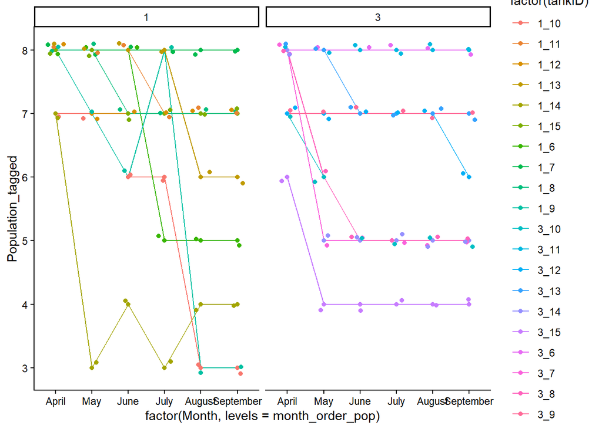

```r
ds1 <- ds1 %>%
  # Filter to keep only ID_fish where a mass exists for Month == "May"
  filter(ID_fish %in% ID_fish[Month == "May" & !is.na(mass)])


month_order <- c("May", "June", "July", "August", "September") # assign chronological order to Month (otherwise alphabetical)
ds1$Month <- factor(ds1$Month, levels = month_order) # assign month_order to factor variable "Month" in ds1

month_order_pop <- c("April", "May", "June", "July", "August", "September") # assign chronological order to Month (otherwise alphabetical)

min_mass = min(ds1$mass)
min_log_mass = min(ds1$log_mass)

min_finalmass = min(((ds1[which(!is.na(ds1$Final_Mass_g)),]$Final_Mass_g)))
min_log_finalmass = min((log10(ds1[which(!is.na(ds1$Final_Mass_g)),]$Final_Mass_g)))


# format data columns and generate centred and log-scaled variables
ds1 <- ds1 %>%
  mutate(
    mass_centre = mass - min_mass,                                  # centred mass
    log_mass_centre = log_mass - log10(min_mass),                   # log-scaled centred mass
    Temp_class = as.factor(Temp_class),                             # set temperature treatments as factors
    SMR1 = log10(SMR),                                              # log-scaled SMR
    RMR1 = log10(RMR),                                              # log-scaled RMR
    MMR1 = log10(MMR),                                              # log-scaled MMR
    mass1 = log_mass,                                               # log-scaled mass
    Month_int = case_when(Month == "May" ~ 1,
                          Month == "June" ~ 2,
                          Month == "July" ~ 3,
                          Month == "August" ~ 4,
                          Month == "September" ~ 5),
    Month_centred = Month_int - 1,                                  # left-centred mass so May is the intercept
    Month_centred_factor = as.factor(Month_centred),                # set centred month as factors
    Rack = as.integer(Rack),                                        # set rack ID to integer (for now)
    Bin = as.integer(Bin),                                          # set bin ID to integer (for now)
    finalmass_centre = Final_Mass_g - min_finalmass,                # centre last mass measurement taken
    log_finalmass_centre = log10(Final_Mass_g) - min_log_finalmass, # log-scaled and centred final mass
    log_fatmass = log10(Fat_mass_g)                                 # log-scaled fat mass
  )

ds1 <- tidyr::unite(data = ds1, Rack, Bin, col = "tankID", sep = "_") # merge rack and bin data into one identifier, call it tankID

#read in density data table, call it BinCounts
setwd(raw_data_wd)
BinCounts <- read_excel("BinCounts.xlsx", sheet = "data")

tb_density <- BinCounts %>%
  group_by_(
    "Month",
    "Rack") %>%
  summarise(
    Population = sum(Population_tagged)) %>%
  mutate(
    Month = factor(Month, levels = month_order_pop))

ggplot(BinCounts, aes(x = factor(Month, levels = month_order_pop), y = Population_tagged, group = tankID, color = factor(tankID))) +
  geom_line() +
  geom_point() +
  geom_jitter(height = 0.1, width = 0.25) +
  facet_grid(.~Rack) +
  theme_classic()
```

```r
#merge BinCounts and ds1
ds1 <- left_join(ds1, BinCounts %>% dplyr::select("Month", "tankID", "Population"), by = c("Month", "tankID"))

#reformat Sex variable so that both unknown and immature fish are "NA"
ds1$Sex <- ifelse(ds1$Sex == "I", NA, ds1$Sex)

# rename "population" as density, set tankID as factor
ds1 <- ds1 %>%
  rename(
    Density = Population
  ) %>%
  mutate(
    tankID = as.factor(tankID)
  )

# check structure of ds1
str(ds1)
```

```
## tibble [624 × 41] (S3: tbl_df/tbl/data.frame)
##  $ Resp_Day            : num [1:624] 13 13 13 13 13 13 13 13 13 13 ...
##  $ ID_fish             : num [1:624] 81 82 83 84 85 86 87 88 89 90 ...
##  $ chamber_ch          : chr [1:624] "A1" "B3" "B4" "A2" ...
##  $ Temp_class          : Factor w/ 2 levels "18","23": 2 2 2 2 2 2 2 2 2 2 ...
##  $ RMR                 : num [1:624] 0.952 0.412 0.712 1.016 0.876 ...
##  $ RMR_var             : num [1:624] 0.0149 0.0135 0.0429 0.0696 0.0454 ...
##  $ RMR_perc            : num [1:624] 1.57 3.28 6.02 6.85 5.18 ...
##  $ time_start          : POSIXct[1:624], format: "2023-05-22 17:53:00" "2023-05-22 17:53:00" ...
##  $ time_end            : POSIXct[1:624], format: "2023-05-23 08:03:00" "2023-05-23 08:03:00" ...
##  $ mass                : num [1:624] 2.65 0.81 1.78 2.73 2.29 0.98 2.04 2.43 2.31 1.65 ...
##  $ length              : num [1:624] 77 62 73 78 80 64 80 77 78 68 ...
##  $ volume_net          : num [1:624] 707 709 708 707 708 ...
##  $ SMR                 : num [1:624] 0.845 0.284 0.53 0.804 0.707 ...
##  $ MMR                 : num [1:624] 1.43 1.11 1.44 1.64 1.69 ...
```

[output cut: 27 more lines]

```r
head(ds1)
```

```
## # A tibble: 6 × 41
##   Resp_Day ID_fish chamber_ch Temp_class   RMR RMR_var RMR_perc
##      <dbl>   <dbl> <chr>      <fct>      <dbl>   <dbl>    <dbl>
## 1       13      81 A1         23         0.952  0.0149     1.57
## 2       13      82 B3         23         0.412  0.0135     3.28
## 3       13      83 B4         23         0.712  0.0429     6.02
## 4       13      84 A2         23         1.02   0.0696     6.85
## 5       13      85 A4         23         0.876  0.0454     5.18
## 6       13      86 A3         23         0.751  0.0504     6.71
## # ℹ 34 more variables: time_start <dttm>, time_end <dttm>, mass <dbl>,
## #   length <dbl>, volume_net <dbl>, SMR <dbl>, MMR <dbl>,
## #   log_SMR_low10pc <dbl>, log_mass <dbl>, log_RMR <dbl>, log_MMR <dbl>,
## #   Month <chr>, tankID <fct>, TagID <chr>, Final_Mass_g <dbl>,
## #   Final_Length_mm <int>, Gonad_mass_g <dbl>, Sex <chr>, Fat_mass_g <dbl>,
## #   Ventricle_mass_g <chr>, Otolith_age_y <dbl>, mass_centre <dbl>,
## #   log_mass_centre <dbl>, SMR1 <dbl>, RMR1 <dbl>, MMR1 <dbl>, mass1 <dbl>, …
```

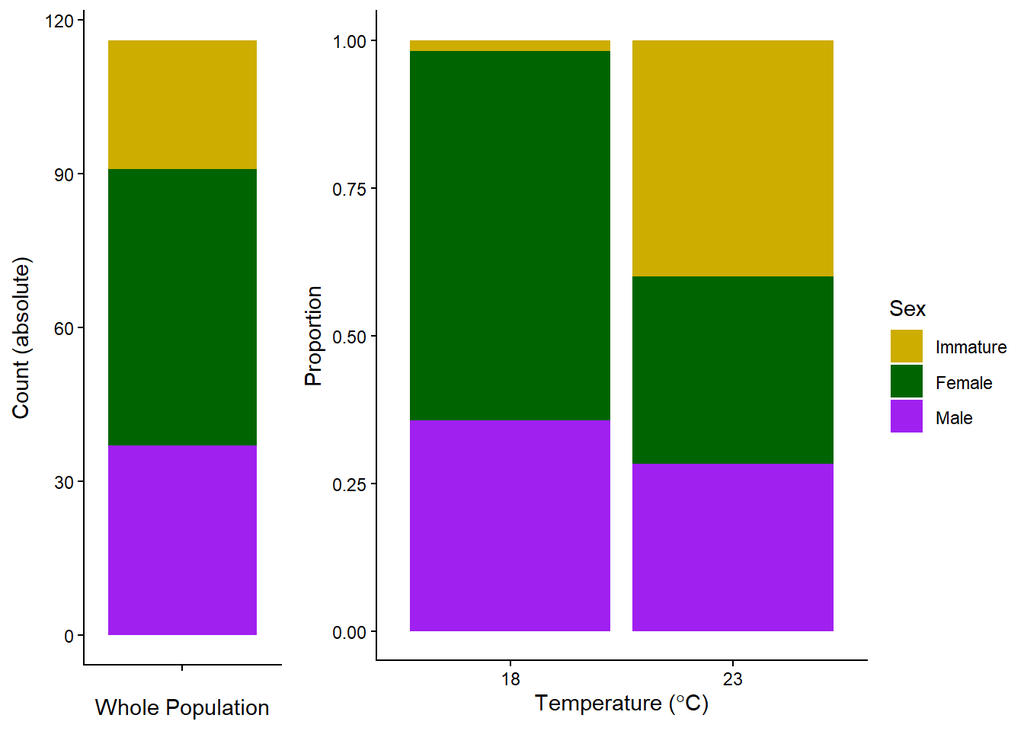

```r
# check sex ratio of population
tb_sexratio <- ds1[which(ds1$Month == "September"),] %>%
  group_by_(
    "Temp_class",
    "Sex"
  ) %>%
  count()

sexorder <- c("Immature", "Female", "Male")

tb_sexratio$Sex <- as.character(tb_sexratio$Sex)
tb_sexratio$Sex[tb_sexratio$Sex==""] <- NA
tb_sexratio$Sex[is.na(tb_sexratio$Sex)] <- "Immature"
tb_sexratio$Sex[tb_sexratio$Sex == "F"] <- "Female"
tb_sexratio$Sex[tb_sexratio$Sex == "M"] <- "Male"
tb_sexratio <- tb_sexratio %>%
  mutate(
    Sex = factor(Sex, levels = sexorder))

fig3b1 <- ggplot(tb_sexratio, aes(x = " ", y = n,  fill = Sex)) +
  geom_bar(position = "stack", stat = "identity") +
  scale_fill_manual(values = c("gold3", "darkgreen", "purple")) +
  labs(x = "Whole Population", y = "Count (absolute)", fill = "Sex") +
  theme_classic()

fig3b2 <- ggplot(tb_sexratio, aes(x = factor(Temp_class), y = n, fill = Sex)) +
  geom_bar(position = "fill", stat = "identity") +
  scale_fill_manual(values = c("gold3", "darkgreen", "purple")) +
  labs(x = expression("Temperature ("*degree*C*")"), y = "Proportion", fill = "Sex") +
  theme_classic()

fig3b <- ggarrange(print(fig3b1), print(fig3b2), ncol = 2, nrow = 1, widths = c(1, 2), align = "v", common.legend = TRUE, legend = "right")

fig3b
```

# GROWTH ANALYSES

## Visualize growth data

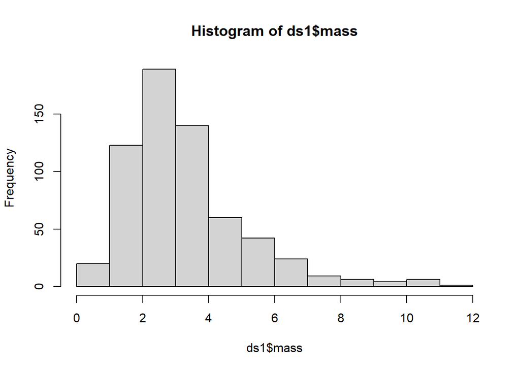

```r
hist(ds1$mass) # plot all mass values to see mass range and most frequent values
```

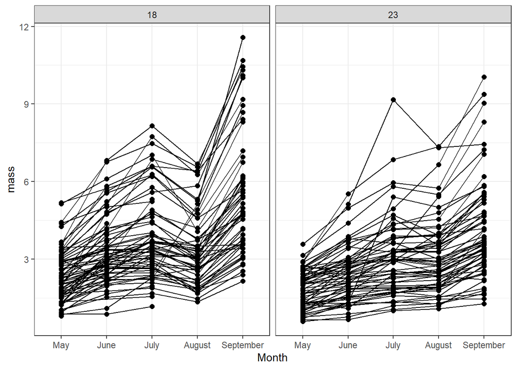

```r
ds1$Month <- factor(ds1$Month, levels = month_order)              # reassign month_order to factor variable "Month" in ds1

ds1$Sex[ds1$Sex == ""] <- NA
ds1$Sex <- factor(ds1$Sex)


# Plot mass over time, connect by ID_fish to show individual trends

ggplot(ds1, aes(x = Month, y = mass, group = ID_fish)) +          # plot raw data by ID
  geom_point(size = 2) +                                          # size of data points
  geom_line() +                                                   # connect points by individual ID
  facet_wrap(. ~ Temp_class) +                                    # produces one plot per temperature treatment
  theme_bw()
```

## Log-linearize mass data

We can also visualise this by plotting log10 mass over log10_x (note that we cannot use log10_y as some masses were < 1 initially)

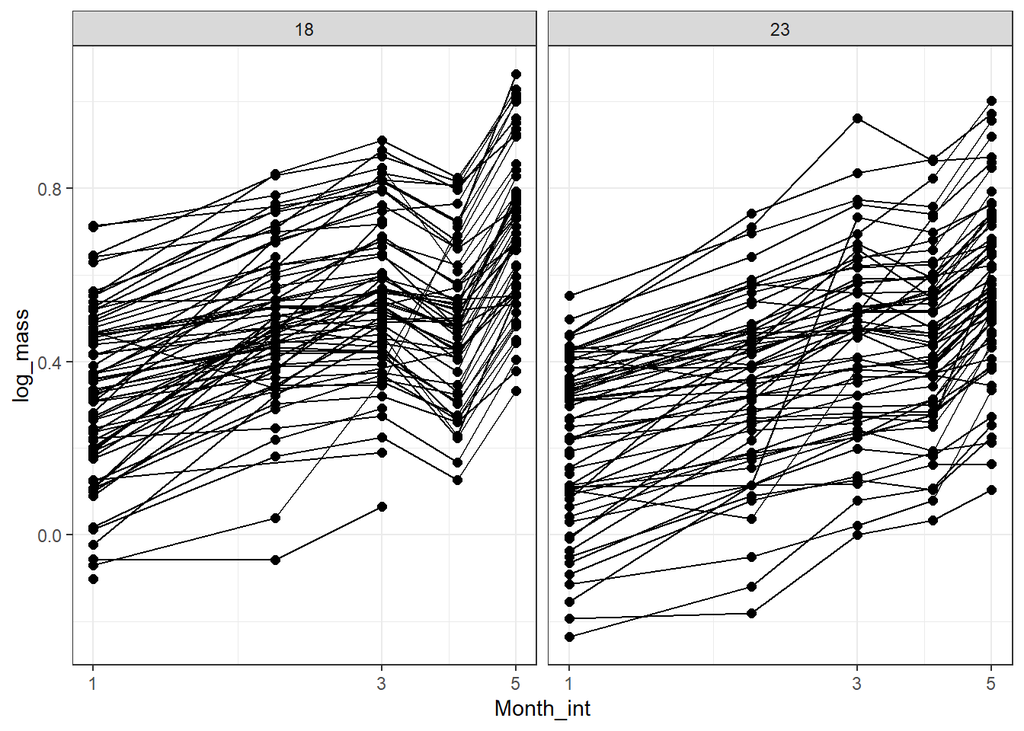

```r
ggplot(ds1, aes(x = Month_int, y = log_mass, group = ID_fish)) +  # plot logged mass data by ID
  geom_point(size = 2) +                                          # size of data points
  geom_line() +                                                   # connect points by individual ID
  facet_wrap(. ~ Temp_class) +                                    # produces one plot per temperature treatment
  theme_bw() +
  scale_x_log10()                                                 # display x-axis on log scale
```

## Univariate growth models for two temperature treatments

```r
ds18 <- ds1[which(ds1$Temp_class == "18"),]                   # subset ds for only fish at 18C
ds23 <- ds1[which(ds1$Temp_class == "23"),]                   # subset ds for only fish at 23C

mass18_mod<-lme4::lmer(log_mass ~ Month + (1 + Month_int|ID_fish), # model structure, 18C only
           data=ds18, REML = T)

summary(mass18_mod)                                 # generate model output
```

```
## Linear mixed model fit by REML ['lmerMod']
## Formula: log_mass ~ Month + (1 + Month_int | ID_fish)
##    Data: ds18
##
## REML criterion at convergence: -492
##
## Scaled residuals:
##     Min      1Q  Median      3Q     Max
## -3.8214 -0.4648  0.0139  0.4865  2.3450
##
## Random effects:
##  Groups   Name        Variance Std.Dev. Corr
##  ID_fish  (Intercept) 0.040770 0.20191
##           Month_int   0.002038 0.04515  -0.57
##  Residual             0.003528 0.05939
## Number of obs: 317, groups:  ID_fish, 72
##
## Fixed effects:
##                Estimate Std. Error t value
## (Intercept)     0.32789    0.02232  14.689
## MonthJune       0.15461    0.01147  13.478
## MonthJuly       0.22113    0.01498  14.761
## MonthAugust     0.15515    0.01989   7.799
## MonthSeptember  0.36370    0.02487  14.622
##
## Correlation of Fixed Effects:
##             (Intr) MnthJn MnthJl MnthAg
## MonthJune   -0.364
## MonthJuly   -0.412  0.629
## MonthAugust -0.410  0.600  0.770
## MonthSptmbr -0.408  0.581  0.776  0.865
```

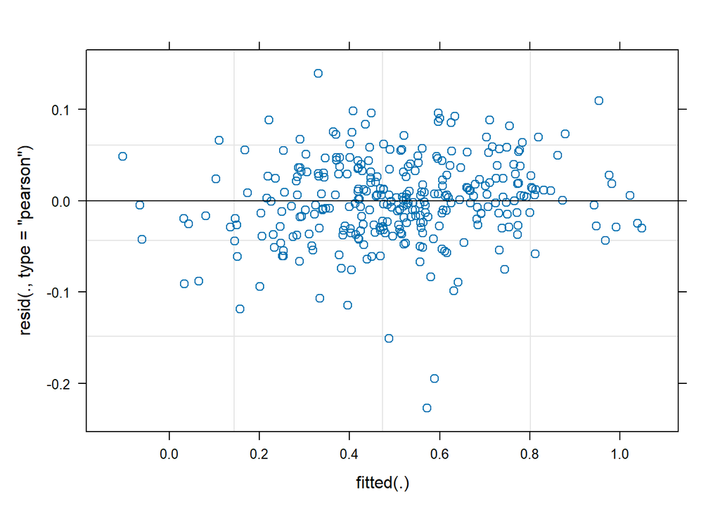

```r
plot(mass18_mod)                                    # residuals plot
```

```r
mass23_mod<-lme4::lmer(log_mass ~ Month + (1 + Month_int|ID_fish), # model structure, 23C only
                 data=ds23, REML=T)

summary(mass23_mod)                                 # generate model output
```

```
## Linear mixed model fit by REML ['lmerMod']
## Formula: log_mass ~ Month + (1 + Month_int | ID_fish)
##    Data: ds23
##
## REML criterion at convergence: -515.4
##
## Scaled residuals:
##     Min      1Q  Median      3Q     Max
## -2.9289 -0.3941 -0.0018  0.5057  4.8187
##
## Random effects:
##  Groups   Name        Variance Std.Dev. Corr
##  ID_fish  (Intercept) 0.040995 0.20247
##           Month_int   0.001445 0.03802  -0.46
##  Residual             0.003138 0.05602
## Number of obs: 307, groups:  ID_fish, 64
##
## Fixed effects:
##                Estimate Std. Error t value
## (Intercept)     0.21996    0.02451   8.974
## MonthJune       0.12091    0.01123  10.771
## MonthJuly       0.21448    0.01402  15.297
## MonthAugust     0.22778    0.01773  12.848
## MonthSeptember  0.35157    0.02193  16.028
##
## Correlation of Fixed Effects:
##             (Intr) MnthJn MnthJl MnthAg
## MonthJune   -0.298
## MonthJuly   -0.335  0.623
## MonthAugust -0.341  0.611  0.773
## MonthSptmbr -0.337  0.589  0.778  0.858
```

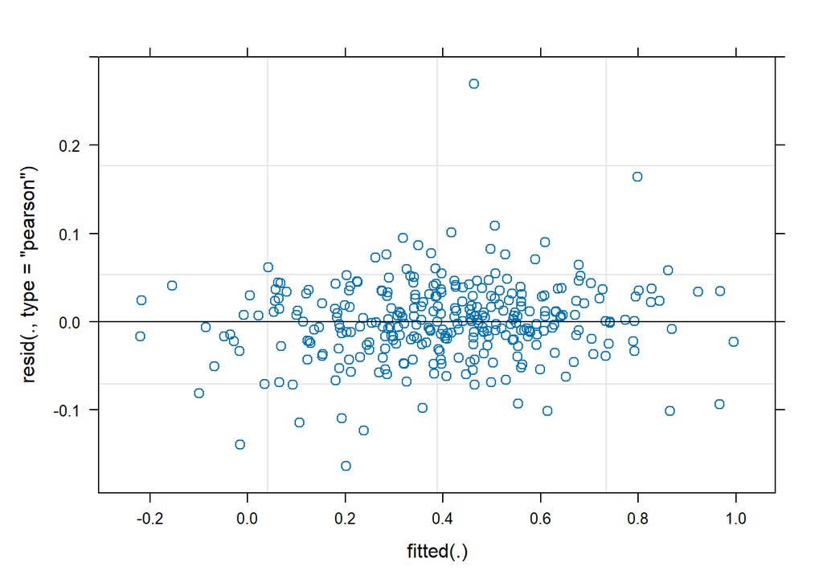

```r
plot(mass23_mod)                                    # residuals plot
```

## Combined growth model

```r
# mass model including both temperature treatments, and their interaction with Month
mass_mod <- lmer(log_mass ~ Month*as.factor(Temp_class) + Sex  + Density + (1 + Month_int|ID_fish),
                 data=ds1, REML=T)

summary(mass_mod)   # generate model output
```

```
## Linear mixed model fit by REML. t-tests use Satterthwaite's method [
## lmerModLmerTest]
## Formula: log_mass ~ Month * as.factor(Temp_class) + Sex + Density + (1 +
##     Month_int | ID_fish)
##    Data: ds1
##
## REML criterion at convergence: -732.3
##
## Scaled residuals:
##     Min      1Q  Median      3Q     Max
## -3.6965 -0.4297  0.0123  0.4659  4.5929
##
## Random effects:
##  Groups   Name        Variance Std.Dev. Corr
##  ID_fish  (Intercept) 0.032801 0.18111
##           Month_int   0.001623 0.04029  -0.54
##  Residual             0.003489 0.05906
## Number of obs: 453, groups:  ID_fish, 91
##
## Fixed effects:
##                                          Estimate Std. Error         df t value
## (Intercept)                              0.287001   0.051703 379.511550   5.551
## MonthJune                                0.157704   0.012697 354.616467  12.420
## MonthJuly                                0.228444   0.016168 237.622029  14.130
## MonthAugust                              0.167240   0.021107 155.507265   7.923
## MonthSeptember                           0.379389   0.025536 111.141150  14.857
## as.factor(Temp_class)23                 -0.059851   0.037534  99.223469  -1.595
## SexM                                    -0.073375   0.033162  88.017749  -2.213
## Density                                  0.011296   0.005978 429.998459   1.890
## MonthJune:as.factor(Temp_class)23       -0.024598   0.019947 352.647746  -1.233
## MonthJuly:as.factor(Temp_class)23       -0.010083   0.025097 226.080174  -0.402
## MonthAugust:as.factor(Temp_class)23      0.060749   0.032152 137.635190   1.889
## MonthSeptember:as.factor(Temp_class)23  -0.023724   0.039367 100.653936  -0.603
##                                        Pr(>|t|)
## (Intercept)                            5.35e-08 ***
## MonthJune                               < 2e-16 ***
## MonthJuly                               < 2e-16 ***
## MonthAugust                            4.15e-13 ***
## MonthSeptember                          < 2e-16 ***
## as.factor(Temp_class)23                  0.1140
```

[output cut: 19 more lines]

```
## MnthJl:.(T_)23  0.219 -0.402 -0.636 -0.496 -0.502 -0.414  0.003 -0.121
## MnA:.(T_)23     0.288 -0.400 -0.511 -0.648 -0.566 -0.425  0.004 -0.201
## MnS:.(T_)23     0.245 -0.384 -0.507 -0.555 -0.639 -0.419  0.003 -0.151
##                MnthJn:.(T_)23 MnthJl:.(T_)23 MA:.(T
## MonthJune
## MonthJuly
## MonthAugust
## MonthSptmbr
## as.fc(T_)23
## SexM
## Density
## MnthJn:.(T_)23
## MnthJl:.(T_)23  0.625
## MnA:.(T_)23     0.608          0.778
## MnS:.(T_)23     0.591          0.785          0.864
```

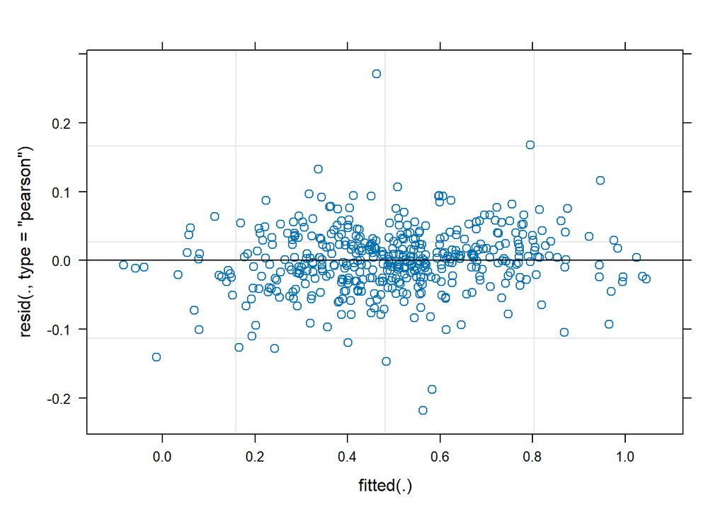

```r
plot(mass_mod)      # residuals plot
```

```r
ranova(mass_mod)    # ANOVA table output to test random effects
```

```
## ANOVA-like table for random-effects: Single term deletions
##
## Model:
## log_mass ~ Month + as.factor(Temp_class) + Sex + Density + (1 + Month_int | ID_fish) + Month:as.factor(Temp_class)
##                                        npar logLik     AIC    LRT Df Pr(>Chisq)
## <none>                                   16 366.13 -700.25
## Month_int in (1 + Month_int | ID_fish)   14 305.38 -582.77 121.48  2  < 2.2e-16
##
## <none>
## Month_int in (1 + Month_int | ID_fish) ***
## ---
## Signif. codes:  0 '***' 0.001 '**' 0.01 '*' 0.05 '.' 0.1 ' ' 1
```

```r
# mass model including both temperature treatments, and their interaction with Month
mass_mod_noMonth <- lmer(log_mass ~ Month*as.factor(Temp_class) + Sex + Density + (1|ID_fish),
                 data=ds1, REML=T)

summary(mass_mod_noMonth)   # generate model output
```

```
## Linear mixed model fit by REML. t-tests use Satterthwaite's method [
## lmerModLmerTest]
## Formula: log_mass ~ Month * as.factor(Temp_class) + Sex + Density + (1 |
##     ID_fish)
##    Data: ds1
##
## REML criterion at convergence: -610.8
##
## Scaled residuals:
##     Min      1Q  Median      3Q     Max
## -4.6634 -0.5041  0.0313  0.4740  3.9635
##
## Random effects:
##  Groups   Name        Variance Std.Dev.
##  ID_fish  (Intercept) 0.022746 0.15082
##  Residual             0.007567 0.08699
## Number of obs: 453, groups:  ID_fish, 91
##
## Fixed effects:
##                                          Estimate Std. Error         df t value
## (Intercept)                              0.304207   0.053767 382.535854   5.658
## MonthJune                                0.157025   0.016791 355.224021   9.352
## MonthJuly                                0.227033   0.017176 361.268479  13.218
## MonthAugust                              0.164380   0.018271 377.508492   8.997
## MonthSeptember                           0.376529   0.018271 377.508492  20.608
## as.factor(Temp_class)23                 -0.061639   0.037779 137.305730  -1.632
## SexM                                    -0.072332   0.033449  88.014836  -2.162
## Density                                  0.008948   0.006287 440.998220   1.423
## MonthJune:as.factor(Temp_class)23       -0.024244   0.026455 353.637257  -0.916
## MonthJuly:as.factor(Temp_class)23       -0.008998   0.026629 355.432235  -0.338
## MonthAugust:as.factor(Temp_class)23      0.063283   0.027233 362.066784   2.324
## MonthSeptember:as.factor(Temp_class)23  -0.021386   0.027107 360.854223  -0.789
##                                        Pr(>|t|)
## (Intercept)                            3.01e-08 ***
## MonthJune                               < 2e-16 ***
## MonthJuly                               < 2e-16 ***
## MonthAugust                             < 2e-16 ***
## MonthSeptember                          < 2e-16 ***
## as.factor(Temp_class)23                  0.1051
## SexM                                     0.0333 *
```

[output cut: 18 more lines]

```
## MnthJl:.(T_)23  0.200 -0.323 -0.637 -0.333 -0.333 -0.360  0.004 -0.120
## MnA:.(T_)23     0.311 -0.328 -0.353 -0.657 -0.381 -0.368  0.006 -0.249
## MnS:.(T_)23     0.296 -0.328 -0.350 -0.375 -0.652 -0.368  0.005 -0.231
##                MnthJn:.(T_)23 MnthJl:.(T_)23 MA:.(T
## MonthJune
## MonthJuly
## MonthAugust
## MonthSptmbr
## as.fc(T_)23
## SexM
## Density
## MnthJn:.(T_)23
## MnthJl:.(T_)23  0.499
## MnA:.(T_)23     0.492          0.509
## MnS:.(T_)23     0.494          0.510          0.529
```

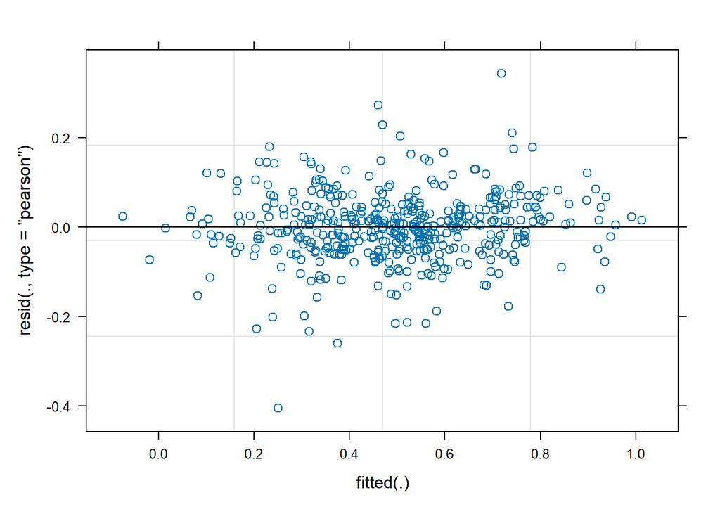

```r
plot(mass_mod_noMonth)      # residuals plot
```

```r
ranova(mass_mod_noMonth)    # ANOVA table output to test random effects
```

```
## ANOVA-like table for random-effects: Single term deletions
##
## Model:
## log_mass ~ Month + as.factor(Temp_class) + Sex + Density + (1 | ID_fish) + Month:as.factor(Temp_class)
##               npar logLik     AIC    LRT Df Pr(>Chisq)
## <none>          14 305.38 -582.77
## (1 | ID_fish)   13 121.89 -217.78 366.99  1  < 2.2e-16 ***
## ---
## Signif. codes:  0 '***' 0.001 '**' 0.01 '*' 0.05 '.' 0.1 ' ' 1
```

```r
# mass model with random intercepts by temp treatment
mass_mod_trtint <- lmer(log_mass ~ Month*as.factor(Temp_class) + Sex + Density + (0 + Month_int|Temp_class),
                 data=ds1, REML=T)

summary(mass_mod_trtint)   # generate model output
```

```
## Linear mixed model fit by REML. t-tests use Satterthwaite's method [
## lmerModLmerTest]
## Formula: log_mass ~ Month * as.factor(Temp_class) + Sex + Density + (0 +
##     Month_int | Temp_class)
##    Data: ds1
##
## REML criterion at convergence: -243.8
##
## Scaled residuals:
##      Min       1Q   Median       3Q      Max
## -2.86639 -0.70696 -0.01277  0.67903  2.94871
##
## Random effects:
##  Groups     Name      Variance Std.Dev.
##  Temp_class Month_int 0.03024  0.1739
##  Residual             0.03013  0.1736
## Number of obs: 453, groups:  Temp_class, 2
##
## Fixed effects:
##                                          Estimate Std. Error         df t value
## (Intercept)                              0.301995   0.181676 441.000000   1.662
## MonthJune                                0.159454   0.177058 441.000000   0.901
## MonthJuly                                0.229581   0.349405 441.000000   0.657
## MonthAugust                              0.164793   0.522797 441.000000   0.315
## MonthSeptember                           0.376942   0.696419 441.000000   0.541
## as.factor(Temp_class)23                 -0.061299   0.248776 441.000000  -0.246
## SexM                                    -0.073232   0.016703 441.000000  -4.384
## Density                                  0.009287   0.006273 441.000000   1.480
## MonthJune:as.factor(Temp_class)23       -0.026626   0.251518 441.000000  -0.106
## MonthJuly:as.factor(Temp_class)23       -0.011500   0.494684 441.000000  -0.023
## MonthAugust:as.factor(Temp_class)23      0.062917   0.739690 441.000000   0.085
## MonthSeptember:as.factor(Temp_class)23  -0.021724   0.985139 441.000000  -0.022
##                                        Pr(>|t|)
## (Intercept)                              0.0972 .
## MonthJune                                0.3683
## MonthJuly                                0.5115
## MonthAugust                              0.7527
## MonthSeptember                           0.5886
## as.factor(Temp_class)23                  0.8055
## SexM                                   1.46e-05 ***
```

[output cut: 18 more lines]

```
## MnthJl:.(T_)23 -0.665 -0.697 -0.706 -0.704 -0.704  0.972  0.001 -0.007
## MnA:.(T_)23    -0.669 -0.697 -0.704 -0.707 -0.706  0.978  0.000 -0.009
## MnS:.(T_)23    -0.671 -0.697 -0.704 -0.706 -0.707  0.981  0.000 -0.006
##                MnthJn:.(T_)23 MnthJl:.(T_)23 MA:.(T
## MonthJune
## MonthJuly
## MonthAugust
## MonthSptmbr
## as.fc(T_)23
## SexM
## Density
## MnthJn:.(T_)23
## MnthJl:.(T_)23  0.983
## MnA:.(T_)23     0.983          0.996
## MnS:.(T_)23     0.982          0.996          0.998
```

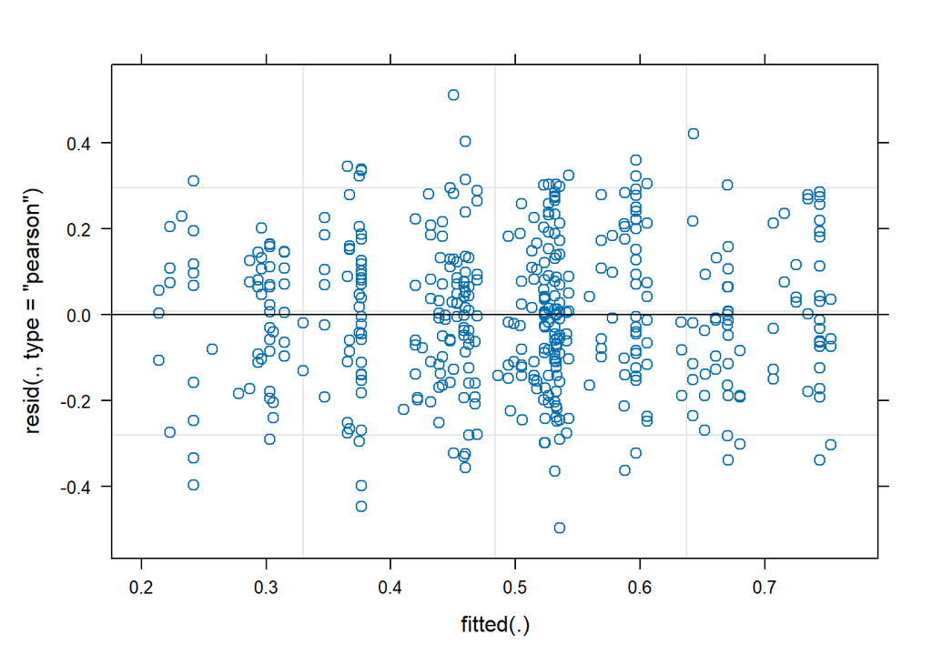

```r
plot(mass_mod_trtint)      # residuals plot
```

```r
ranova(mass_mod_trtint)    # ANOVA table output to test random effects
```

```
## ANOVA-like table for random-effects: Single term deletions
##
## Model:
## log_mass ~ Month + as.factor(Temp_class) + Sex + Density + (0 + Month_int | Temp_class) + Month:as.factor(Temp_class)
##                                           npar logLik     AIC         LRT Df
## <none>                                      14 121.89 -215.78
## Month_int in (0 + Month_int | Temp_class)   14 121.89 -215.78 -1.7053e-13  0
##                                           Pr(>Chisq)
## <none>
## Month_int in (0 + Month_int | Temp_class)
```

```r
mass_mod_sex <- lmer(log_mass ~ 0 + as.factor(Sex):as.factor(Temp_class) + as.factor(Sex):as.factor(Temp_class):Month + Density + (1 + Month_int|ID_fish),
                 data=ds1, REML=T)
summary(mass_mod_sex)
```

```
## Linear mixed model fit by REML. t-tests use Satterthwaite's method [
## lmerModLmerTest]
## Formula:
## log_mass ~ 0 + as.factor(Sex):as.factor(Temp_class) + as.factor(Sex):as.factor(Temp_class):Month +
##     Density + (1 + Month_int | ID_fish)
##    Data: ds1
##
## REML criterion at convergence: -706.5
##
## Scaled residuals:
##     Min      1Q  Median      3Q     Max
## -3.4000 -0.4181  0.0150  0.4378  4.4184
##
## Random effects:
##  Groups   Name        Variance Std.Dev. Corr
##  ID_fish  (Intercept) 0.033320 0.18254
##           Month_int   0.001501 0.03874  -0.56
##  Residual             0.003432 0.05858
## Number of obs: 453, groups:  ID_fish, 91
##
## Fixed effects:
##                                                         Estimate Std. Error
## Density                                                1.228e-02  5.915e-03
## as.factor(Sex)F:as.factor(Temp_class)18                2.817e-01  5.316e-02
## as.factor(Sex)M:as.factor(Temp_class)18                2.026e-01  5.901e-02
## as.factor(Sex)F:as.factor(Temp_class)23                2.237e-01  5.597e-02
## as.factor(Sex)M:as.factor(Temp_class)23                1.435e-01  5.888e-02
## as.factor(Sex)F:as.factor(Temp_class)18:MonthJune      1.598e-01  1.571e-02
## as.factor(Sex)M:as.factor(Temp_class)18:MonthJune      1.544e-01  2.050e-02
## as.factor(Sex)F:as.factor(Temp_class)23:MonthJune      1.078e-01  2.098e-02
## as.factor(Sex)M:as.factor(Temp_class)23:MonthJune      1.617e-01  2.225e-02
## as.factor(Sex)F:as.factor(Temp_class)18:MonthJuly      2.577e-01  1.971e-02
## as.factor(Sex)M:as.factor(Temp_class)18:MonthJuly      1.797e-01  2.557e-02
## as.factor(Sex)F:as.factor(Temp_class)23:MonthJuly      1.689e-01  2.602e-02
## as.factor(Sex)M:as.factor(Temp_class)23:MonthJuly      2.739e-01  2.757e-02
## as.factor(Sex)F:as.factor(Temp_class)18:MonthAugust    1.978e-01  2.530e-02
## as.factor(Sex)M:as.factor(Temp_class)18:MonthAugust    1.170e-01  3.257e-02
## as.factor(Sex)F:as.factor(Temp_class)23:MonthAugust    1.757e-01  3.274e-02
## as.factor(Sex)M:as.factor(Temp_class)23:MonthAugust    2.868e-01  3.466e-02
## as.factor(Sex)F:as.factor(Temp_class)18:MonthSeptember 4.041e-01  3.066e-02
```

[output cut: 34 more lines]

```
## as.factor(Sex)M:as.factor(Temp_class)23:MonthJune      2.46e-12 ***
## as.factor(Sex)F:as.factor(Temp_class)18:MonthJuly       < 2e-16 ***
## as.factor(Sex)M:as.factor(Temp_class)18:MonthJuly      2.43e-11 ***
## as.factor(Sex)F:as.factor(Temp_class)23:MonthJuly      5.45e-10 ***
## as.factor(Sex)M:as.factor(Temp_class)23:MonthJuly       < 2e-16 ***
## as.factor(Sex)F:as.factor(Temp_class)18:MonthAugust    9.26e-13 ***
## as.factor(Sex)M:as.factor(Temp_class)18:MonthAugust    0.000455 ***
## as.factor(Sex)F:as.factor(Temp_class)23:MonthAugust    3.63e-07 ***
## as.factor(Sex)M:as.factor(Temp_class)23:MonthAugust    1.39e-13 ***
## as.factor(Sex)F:as.factor(Temp_class)18:MonthSeptember  < 2e-16 ***
## as.factor(Sex)M:as.factor(Temp_class)18:MonthSeptember 1.75e-13 ***
## as.factor(Sex)F:as.factor(Temp_class)23:MonthSeptember 1.26e-10 ***
## as.factor(Sex)M:as.factor(Temp_class)23:MonthSeptember  < 2e-16 ***
## ---
## Signif. codes:  0 '***' 0.001 '**' 0.01 '*' 0.05 '.' 0.1 ' ' 1
```

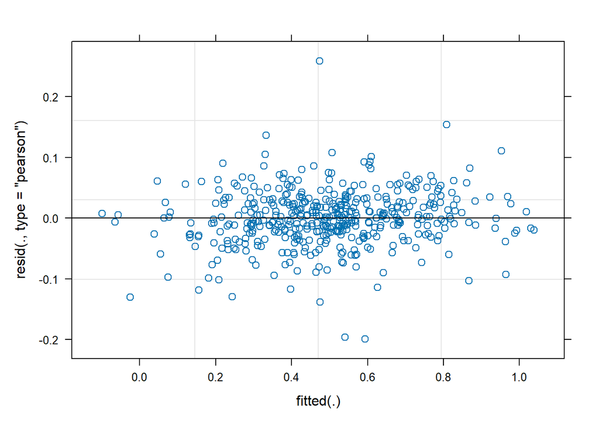

```r
plot(mass_mod_sex)
```

## Plot predicted mean level trend in mass over time, by temperature

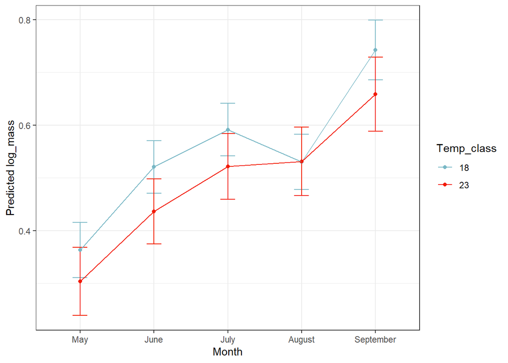

```r
pred <- ggpredict(mass_mod, terms = c("Month", "Temp_class")) # generate trend lines for the two temperature treatments

ggplot() +
    geom_errorbar(
      data = pred,
      aes(x=x, ymin = conf.low, ymax = conf.high, color = group, group = group), width = 0.2) +   # add 95% confidence interval bars
  geom_point(
    data = pred,
    aes(x = x, y = predicted, color = group, group = group)) +                                    # predicted level by temp*month
  geom_line(
    data = pred,
    aes(x = x, y = predicted, color = group, group = group)) +                                    # show level trend over time
  labs(
    x = "Month",
    y = "Predicted log_mass",
    color = "Temp_class") +
  theme_bw() +
  scale_color_manual(values = c("#78B7C5", "#F21A00"))
```

## F test on interaction effect

```r
anova(mass_mod, type = "3") # type 3 anova because we expect a meaningful interaction
```

```
## Type III Analysis of Variance Table with Satterthwaite's method
##                              Sum Sq Mean Sq NumDF  DenDF  F value    Pr(>F)
## Month                       1.68541 0.42135     4 205.57 120.7818 < 2.2e-16 ***
## as.factor(Temp_class)       0.01090 0.01090     1  88.16   3.1235   0.08063 .
## Sex                         0.01708 0.01708     1  88.02   4.8958   0.02951 *
## Density                     0.01246 0.01246     1 430.00   3.5706   0.05948 .
## Month:as.factor(Temp_class) 0.10282 0.02571     4 201.73   7.3687 1.472e-05 ***
## ---
## Signif. codes:  0 '***' 0.001 '**' 0.01 '*' 0.05 '.' 0.1 ' ' 1
```

## Generate fitted data

```r
z_mass<-augment(mass_mod)                             # get variables and fitted values from model
head(z_mass)
```

```
## # A tibble: 6 × 19
##   .rownames log_mass Month `as.factor(Temp_class)` Sex   Density Month_int
##   <chr>        <dbl> <fct> <fct>                   <fct>   <dbl>     <dbl>
## 1 1           0.423  May   23                      F           8         1
## 2 2          -0.0915 May   23                      M           8         1
## 3 3           0.250  May   23                      F           8         1
## 4 4           0.436  May   23                      M           8         1
## 5 5           0.360  May   23                      M           8         1
## 6 7           0.310  May   23                      M           8         1
## # ℹ 12 more variables: ID_fish <dbl>, .fitted <dbl>, .resid <dbl>, .hat <dbl>,
## #   .cooksd <dbl>, .fixed <dbl>, .mu <dbl>, .offset <dbl>, .sqrtXwt <dbl>,
## #   .sqrtrwt <dbl>, .weights <dbl>, .wtres <dbl>
```

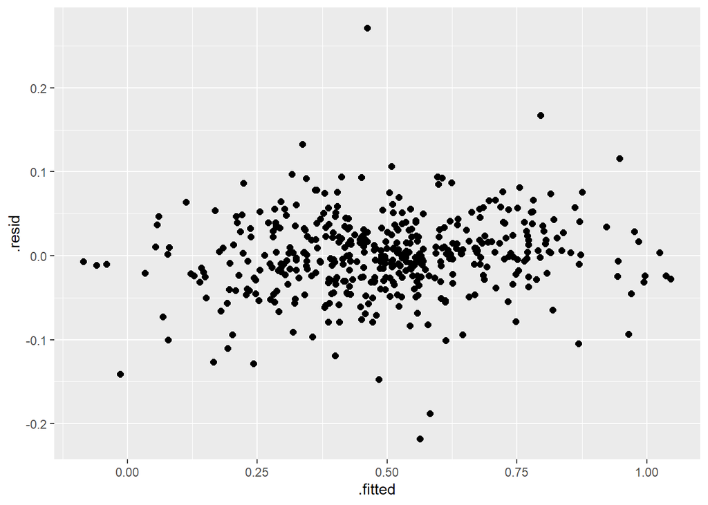

```r
##### check assumptions: plot all residual values against the fitted
ggplot(z_mass, aes(x = .fitted, y = .resid)) +   # same plot as before
  geom_point(size = 2)
```

# FIGURE 1

```r
fig1.1 <- ggplot(z_mass, aes(x = Month, y = log_mass, group = ID_fish)) +
  geom_line(aes(y = .fitted, color = `as.factor(Temp_class)`),             # note this will look odd if there are additional fixed effects
            alpha = 0.6) +
  theme_classic() +
  labs(x = "Month", y = expression(log[10]~(mass~(g))), color = expression("Temperature ("*degree*C*")")) +
  ylim(-0.24,1) +
  scale_color_manual(values  = c("#78B7C5", "#F21A00"))

fig1.2 <- ggplot() +
 geom_errorbar(
      data = pred,
      aes(x=x, ymin = conf.low, ymax = conf.high, color = group, group = group), width = 0.2, alpha = 0.3) +      # add 95% confidence interval bars
  geom_line(
    data = pred,
    aes(x = x, y = predicted, color = group, group = group),
            size = 1) +
  labs(
    x = "Month",
    y = expression(log[10]~(mass~(g))),
    color = expression("Temperature ("*degree*C*")")) +
  theme_classic() +
  ylim(-0.24,1) +
  scale_color_manual(values = c("#78B7C5", "#F21A00"))

fig1 <- ggarrange(print(fig1.1 + rremove("xlab") + rremove ("ylab")),
                  print(fig1.2 + rremove("xlab") + rremove ("ylab")),
                           ncol = 2, nrow = 1, widths = c(1, 1.1),
                           align = "v",
                           common.legend = TRUE,
                           legend = "right")

require(grid)

jpeg(file = "Fig1.jpeg", width=960, height=480, units = "px")
annotate_figure(
  fig1,
  bottom = textGrob("Month"),
  left = textGrob(
    expression(log[10]~(mass~(g))),
    rot = 90,          # Rotate the y-axis label 90 degrees
    gp = gpar(fontsize = 12)  # Optionally adjust the font size
  )
)

setwd(figures_wd)
jpeg(file = "Fig1.jpeg", width=960, height=480, units = "px")
annotate_figure(
  fig1,
  bottom = textGrob("Month"),
  left = textGrob(
    expression(log[10]~(mass~(g))),
    rot = 90,          # Rotate the y-axis label 90 degrees
    gp = gpar(fontsize = 12)  # Optionally adjust the font size
  )
)
dev.off()
```

# SMR MODEL

## Visualize SMR data

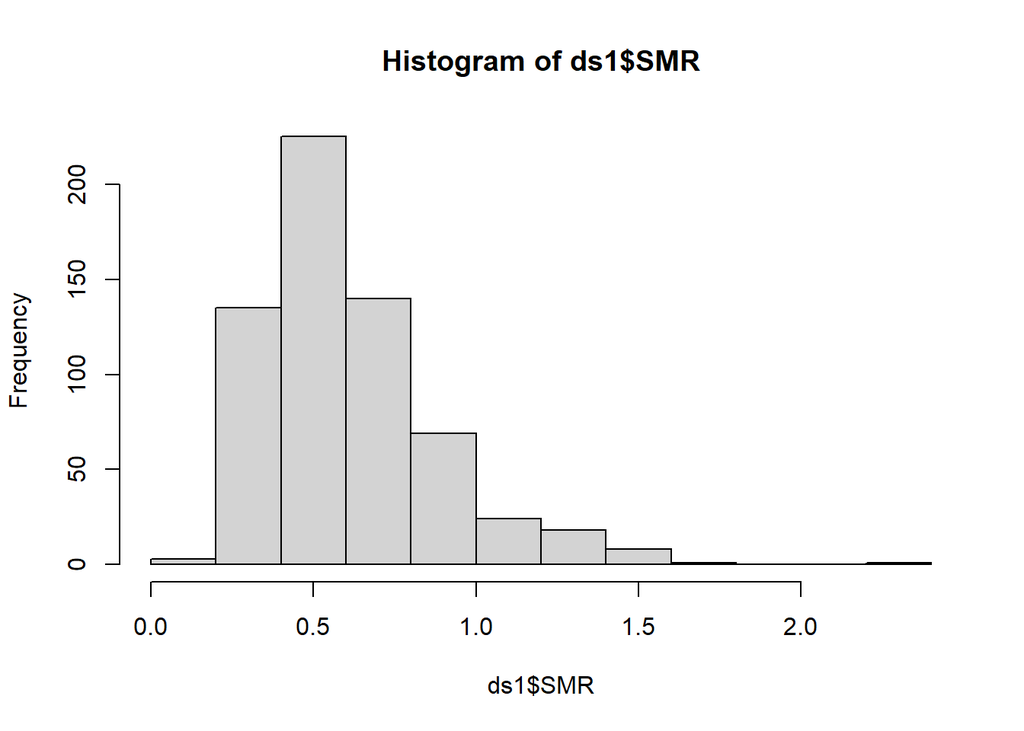

```r
hist(ds1$SMR)        # plot all raw SMR values in a histogram, note skewness
```

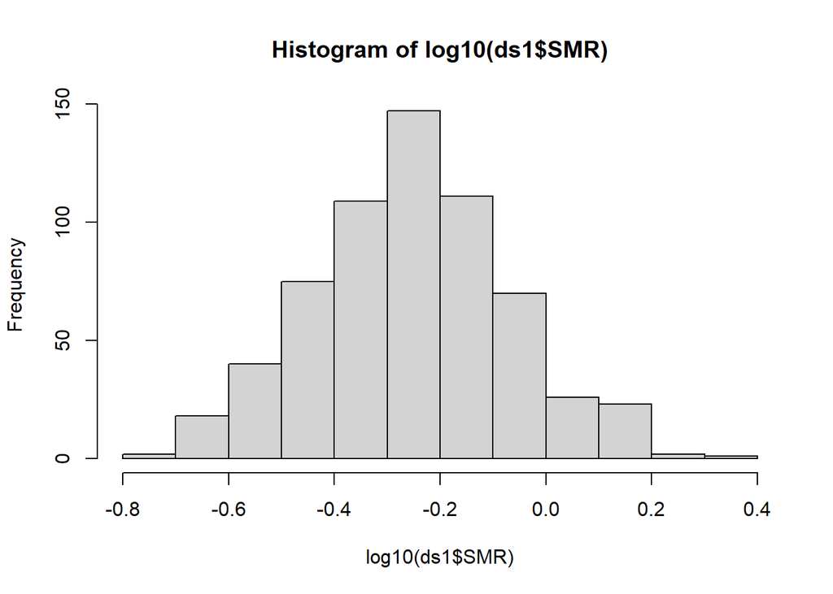

```r
hist(log10(ds1$SMR)) # plot all log-SMR values in a histogram
```

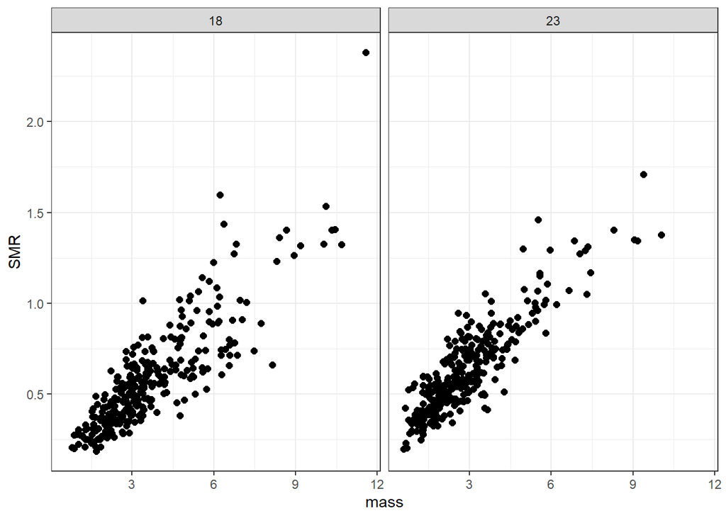

```r
ggplot(ds1, aes(x = mass, y = SMR, group = ID_fish)) +          # plot raw SMR data by ID against mass
  geom_point(size = 2) +                                        # size of data points
  facet_wrap(. ~ Temp_class) +                                  # produces one plot per temperature treatment
  theme_bw()
```

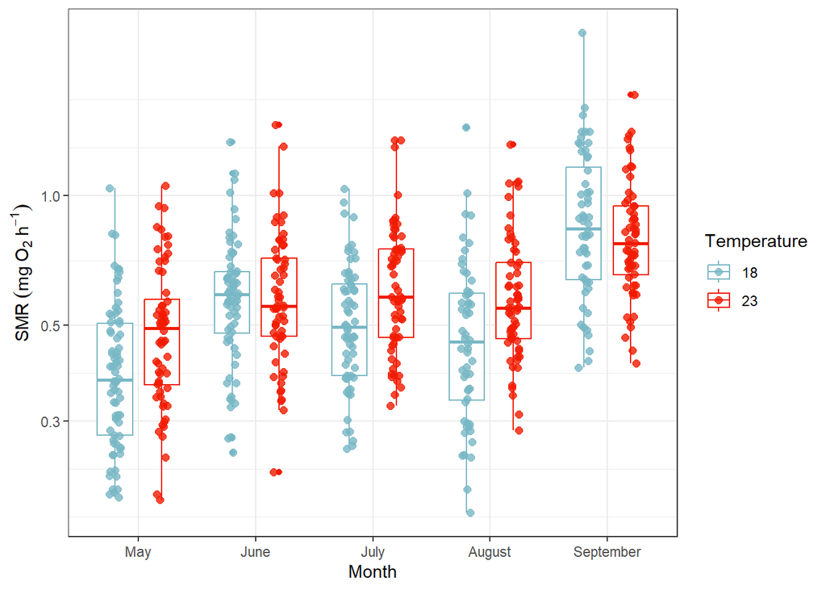

```r
#SMR plotted over time, note that SMR is not mass-standardized and the mass range has changed over time as well.
ggplot(ds1, aes(x = factor(Month), y = SMR, color = factor(Temp_class))) +
  geom_boxplot(position = position_dodge(width = 0.8), width = 0.6) +
  geom_point(position = position_jitterdodge(jitter.width = 0.2, dodge.width = 0.8), size = 2, alpha = 0.8) +
  labs(x = "Month", y = expression(SMR~(mg~O[2]~h^-1)), color = "Temperature") +
  theme_bw() +
  scale_color_manual(values = c("#78B7C5", "#F21A00")) +
  scale_y_log10()
```

## Visualize log-mass and SMR relationship

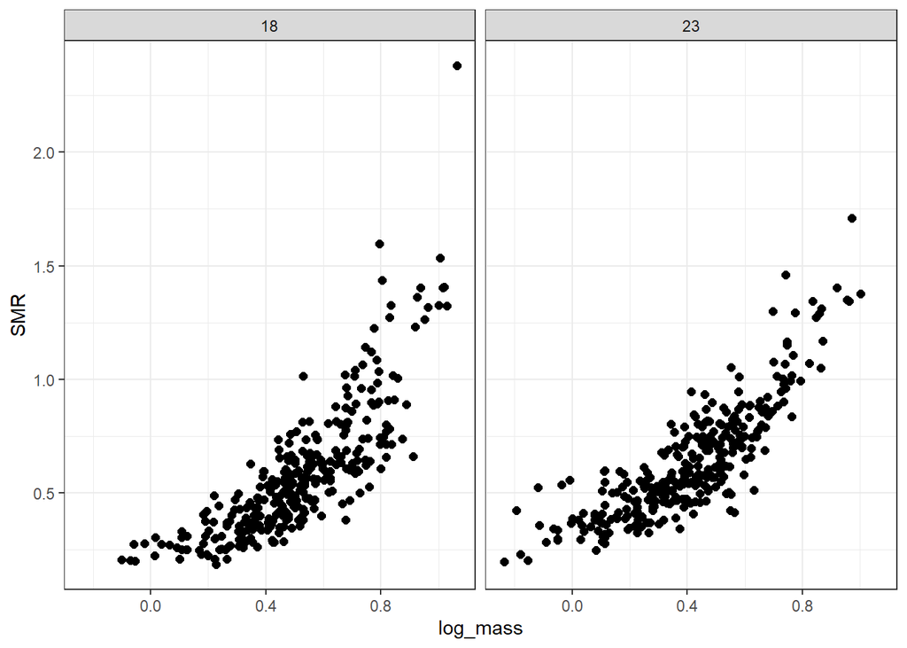

```r
ggplot(ds1, aes(x = log_mass, y = SMR, group = ID_fish)) +          # plot raw SMR data by ID against log10(mass)
  geom_point(size = 2) +                                            # size of data points
  facet_wrap(. ~ Temp_class) +                                      # produces one plot per temperature treatment
  theme_bw()
```

Note that this relationship is non-linear, we expect this to be described by a power function y = a*x^b

This reflects our understanding of the relationship between mass and metabolism, which can be described by the power function y = a*x^b

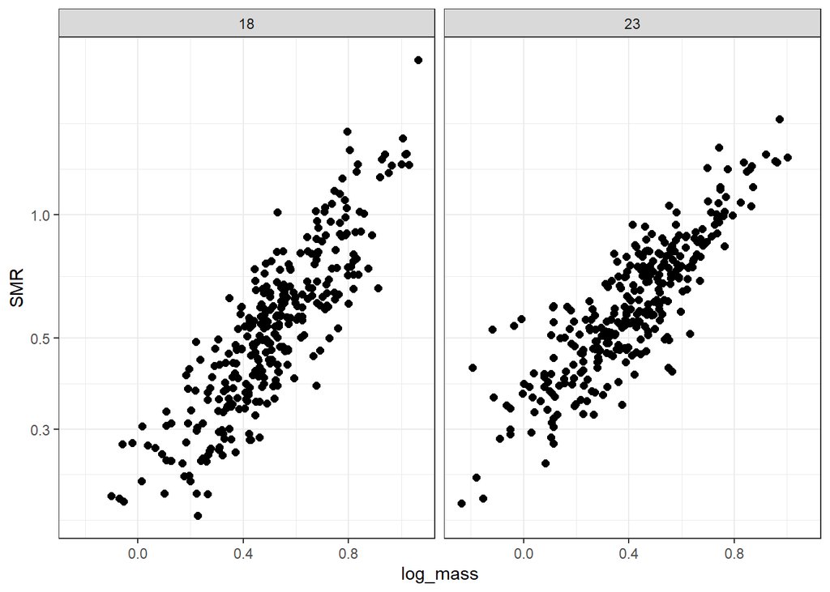

```r
ggplot(ds1, aes(x = log_mass, y = SMR, group = ID_fish)) +          # plot raw SMR data by ID against log10(mass)
  geom_point(size = 2) +                                            # size of data points
  facet_wrap(. ~ Temp_class) +                                      # produces one plot per temperature treatment
  theme_bw() +
  scale_y_log10()                                                   # plot data with log10 scaled y axis
```

The trends become linear when SMR is presented on log scale

## Univariate SMR models for two temperature treatments

```r
# model structure using log10 SMR and mass for fish at 18C only
SMR18_mod<-lmer(log10(SMR) ~ log_mass + (1 + Month_int|ID_fish), # random slopes by month, random intercepts by ID_fish
                 data=ds18, REML = T)

summary(SMR18_mod)                                               # generate model output
```

```
## Linear mixed model fit by REML. t-tests use Satterthwaite's method [
## lmerModLmerTest]
## Formula: log10(SMR) ~ log_mass + (1 + Month_int | ID_fish)
##    Data: ds18
##
## REML criterion at convergence: -553.6
##
## Scaled residuals:
##      Min       1Q   Median       3Q      Max
## -2.68074 -0.73671  0.06691  0.70906  2.73287
##
## Random effects:
##  Groups   Name        Variance  Std.Dev. Corr
##  ID_fish  (Intercept) 8.846e-05 0.009405
##           Month_int   1.173e-06 0.001083 -1.00
##  Residual             9.791e-03 0.098948
## Number of obs: 317, groups:  ID_fish, 72
##
## Fixed effects:
##              Estimate Std. Error        df t value Pr(>|t|)
## (Intercept)  -0.67894    0.01421 142.86363  -47.77   <2e-16 ***
## log_mass      0.78094    0.02570 194.48211   30.38   <2e-16 ***
## ---
## Signif. codes:  0 '***' 0.001 '**' 0.01 '*' 0.05 '.' 0.1 ' ' 1
##
## Correlation of Fixed Effects:
##          (Intr)
## log_mass -0.919
## optimizer (nloptwrap) convergence code: 0 (OK)
## boundary (singular) fit: see help('isSingular')
```

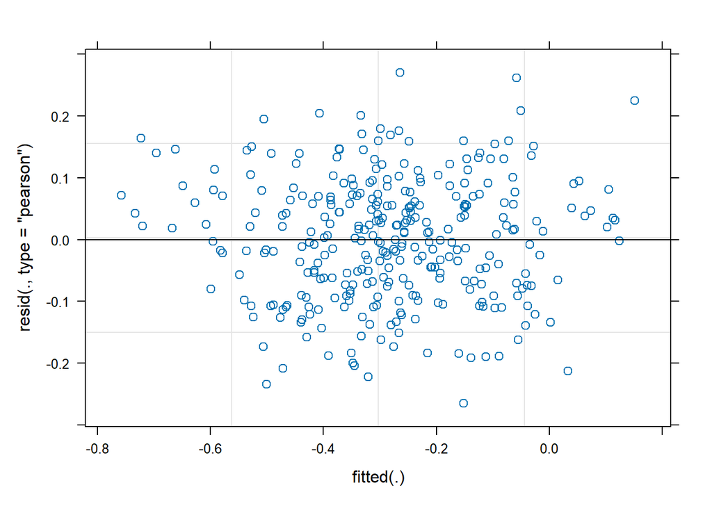

```r
plot(SMR18_mod)                                                  # plot model residuals
```

```r
ranova(SMR18_mod)                                                # anova-like test shows insignificant random slopes
```

```
## ANOVA-like table for random-effects: Single term deletions
##
## Model:
## log10(SMR) ~ log_mass + (1 + Month_int | ID_fish)
##                                        npar logLik     AIC       LRT Df
## <none>                                    6 276.79 -541.57
## Month_int in (1 + Month_int | ID_fish)    4 276.78 -545.56 0.0096633  2
##                                        Pr(>Chisq)
## <none>
## Month_int in (1 + Month_int | ID_fish)     0.9952
```

```r
SMR18_mod_1<-lmer(log10(SMR) ~ log_mass + (1 |ID_fish),          # random slopes term removed
                 data=ds18, REML = T)

summary(SMR18_mod_1)                                             # generate model output
```

```
## Linear mixed model fit by REML. t-tests use Satterthwaite's method [
## lmerModLmerTest]
## Formula: log10(SMR) ~ log_mass + (1 | ID_fish)
##    Data: ds18
##
## REML criterion at convergence: -553.6
##
## Scaled residuals:
##     Min      1Q  Median      3Q     Max
## -2.6860 -0.7401  0.0462  0.7148  2.7433
##
## Random effects:
##  Groups   Name        Variance  Std.Dev.
##  ID_fish  (Intercept) 1.063e-17 3.261e-09
##  Residual             9.832e-03 9.916e-02
## Number of obs: 317, groups:  ID_fish, 72
##
## Fixed effects:
##              Estimate Std. Error        df t value Pr(>|t|)
## (Intercept)  -0.67878    0.01415 315.00000  -47.96   <2e-16 ***
## log_mass      0.78058    0.02562 315.00000   30.46   <2e-16 ***
## ---
## Signif. codes:  0 '***' 0.001 '**' 0.01 '*' 0.05 '.' 0.1 ' ' 1
##
## Correlation of Fixed Effects:
##          (Intr)
## log_mass -0.919
## optimizer (nloptwrap) convergence code: 0 (OK)
## boundary (singular) fit: see help('isSingular')
```

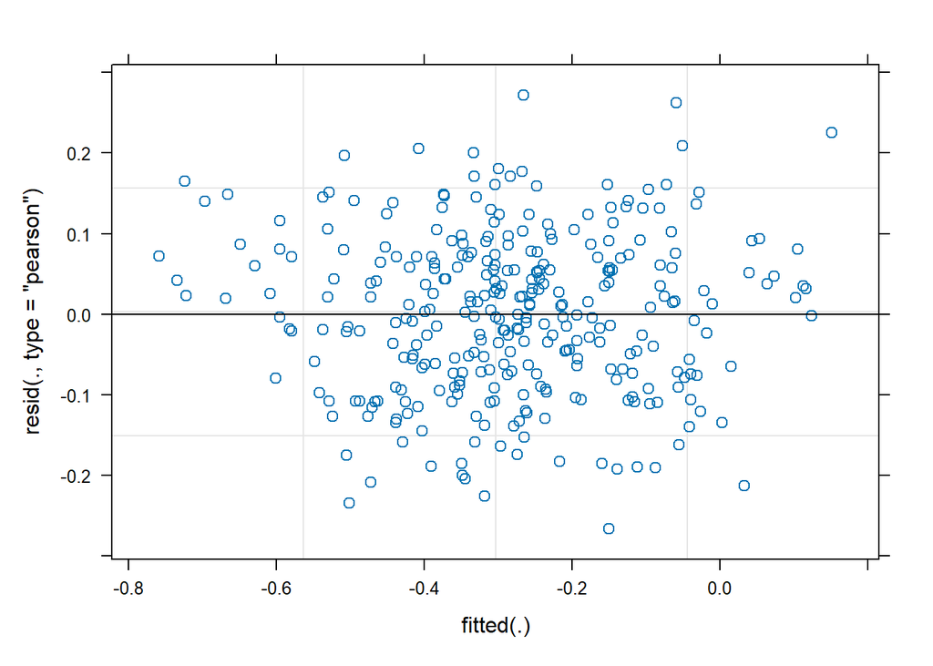

```r
plot(SMR18_mod_1)                                                # plot model residuals
```

```r
ranova(SMR18_mod_1)                                              # anova-like test shows insignificant random intercepts, but retain in model for testing
```

```
## ANOVA-like table for random-effects: Single term deletions
##
## Model:
## log10(SMR) ~ log_mass + (1 | ID_fish)
##               npar logLik     AIC LRT Df Pr(>Chisq)
## <none>           4 276.78 -545.56
## (1 | ID_fish)    3 276.78 -547.56   0  1          1
```